# 6 Analysis of Longitudinal Data

## Task 1: RATS

**Implement the analyses of Chapter 8 of MABS using the RATS data. (0-7 points: 0-4 points for graphs or analysis results + 0-3 points for their interpretations)**

```r
library(dplyr); library(tidyr); library(ggplot2); library(psych); library(kableExtra); library(lme4);
library(GGally); library(corrplot)
options(scipen=999)

RATSL <- read.table("data/RATSL.csv", sep = ",", header = T, row.names = 1)
RATSL <- within(RATSL, {
  Group <- factor(Group)
  ID <- factor(ID)
})
```

### The RATS data

**Table 1** Variables in the dataset

| Variables | Information |
| --- | --- |
| ID | rat id |
| Group | treatment group (diet) |
| WD | day of measurement from the start of the study |
| Weight | an (approximately) weekly bodyweight in grams |
| Time | day of measurement as numeric |

```r
glimpse(RATSL)
```

```
## Observations: 176
## Variables: 5
## $ ID     <fct> 1, 2, 3, 4, 5, 6, 7, 8, 9, 10, 11, 12, 13, 14, 15, 16, ...
## $ Group  <fct> 1, 1, 1, 1, 1, 1, 1, 1, 2, 2, 2, 2, 3, 3, 3, 3, 1, 1, 1...
## $ WD     <fct> WD1, WD1, WD1, WD1, WD1, WD1, WD1, WD1, WD1, WD1, WD1, ...
## $ Weight <int> 240, 225, 245, 260, 255, 260, 275, 245, 410, 405, 445, ...
## $ Time   <int> 1, 1, 1, 1, 1, 1, 1, 1, 1, 1, 1, 1, 1, 1, 1, 1, 8, 8, 8...
```

```r
head(RATSL)
```

```
##   ID Group  WD Weight Time
## 1  1     1 WD1    240    1
## 2  2     1 WD1    225    1
## 3  3     1 WD1    245    1
## 4  4     1 WD1    260    1
## 5  5     1 WD1    255    1
## 6  6     1 WD1    260    1
```

```r
tail(RATSL)
```

```
##     ID Group   WD Weight Time
## 171 11     2 WD64    472   64
## 172 12     2 WD64    628   64
## 173 13     3 WD64    525   64
## 174 14     3 WD64    559   64
## 175 15     3 WD64    548   64
## 176 16     3 WD64    569   64
```

```r
summary(RATSL)
```

```
##        ID      Group        WD         Weight           Time
##  1      : 11   1:88   WD1    :16   Min.   :225.0   Min.   : 1.00
##  2      : 11   2:44   WD15   :16   1st Qu.:267.0   1st Qu.:15.00
##  3      : 11   3:44   WD22   :16   Median :344.5   Median :36.00
##  4      : 11          WD29   :16   Mean   :384.5   Mean   :33.55
##  5      : 11          WD36   :16   3rd Qu.:511.2   3rd Qu.:50.00
##  6      : 11          WD43   :16   Max.   :628.0   Max.   :64.00
##  (Other):110          (Other):80
```

```r
describe(RATSL) %>% kable(digits = 2, caption = "<b>Table 2</b> Descriptives") %>%
  kable_styling(bootstrap_options = c("hover", "striped"))
```

**Table 2** Descriptives

|  | vars | n | mean | sd | median | trimmed | mad | min | max | range | skew | kurtosis | se |
| --- | --- | --- | --- | --- | --- | --- | --- | --- | --- | --- | --- | --- | --- |
| ID* | 1 | 176 | 8.50 | 4.62 | 8.5 | 8.50 | 5.93 | 1 | 16 | 15 | 0.00 | -1.23 | 0.35 |
| Group* | 2 | 176 | 1.75 | 0.83 | 1.5 | 1.69 | 0.74 | 1 | 3 | 2 | 0.49 | -1.39 | 0.06 |
| WD* | 3 | 176 | 6.00 | 3.17 | 6.0 | 6.00 | 4.45 | 1 | 11 | 10 | 0.00 | -1.24 | 0.24 |
| Weight | 4 | 176 | 384.48 | 127.16 | 344.5 | 378.46 | 147.52 | 225 | 628 | 403 | 0.23 | -1.63 | 9.59 |
| Time | 5 | 176 | 33.55 | 19.51 | 36.0 | 33.80 | 20.76 | 1 | 64 | 63 | -0.14 | -1.15 | 1.47 |

There are 3 treatment groups, and the measurement of weight has been done during a 9 week period. The mean weight of the rats is about 384 grams and ranges from 225 to 628 grams.

### Visualizing the data

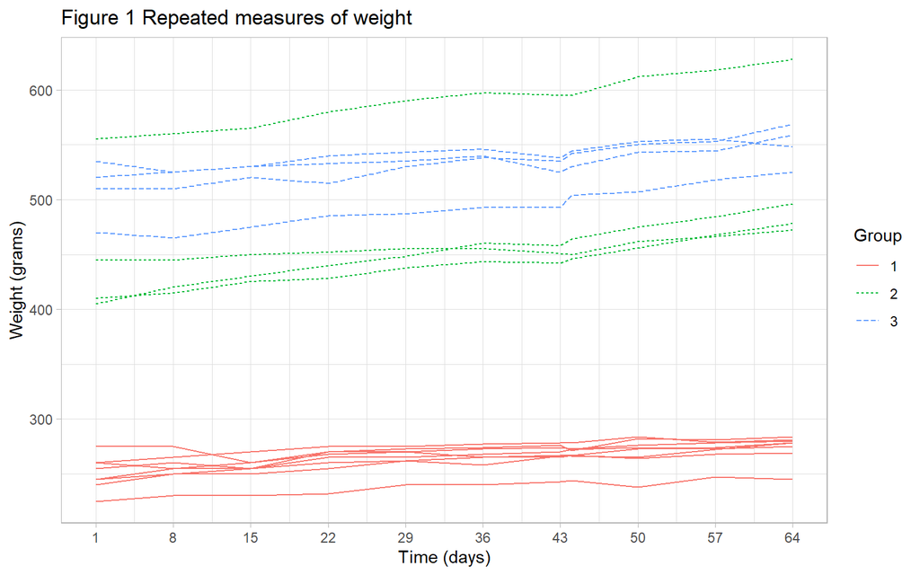

```r
p1 <- ggplot(RATSL, aes(x = Time, y = Weight, group = ID))
p2 <- p1 + geom_line(aes(linetype = Group, color = Group))
p3 <- p2 +  scale_x_continuous(name = "Time (days)", breaks = seq(1, 64, 7)) +
  scale_y_continuous(name = "Weight (grams)")
p4 <- p3 + theme_light() + ggtitle(label = "Figure 1 Repeated measures of weight")
p4
```

A quick look at the data shows that the groups have different starting levels but also that the weight gain seems to be stronger in groups 2 and 3 in comparison to group 1.

```r
# Standardising the scores:
RATSL <- RATSL %>%
  group_by(Time) %>%
  mutate( stdWeight = (Weight - mean(Weight))/sd(Weight) ) %>%
  ungroup()
glimpse(RATSL)
```

```
## Observations: 176
## Variables: 6
## $ ID        <fct> 1, 2, 3, 4, 5, 6, 7, 8, 9, 10, 11, 12, 13, 14, 15, 1...
## $ Group     <fct> 1, 1, 1, 1, 1, 1, 1, 1, 2, 2, 2, 2, 3, 3, 3, 3, 1, 1...
## $ WD        <fct> WD1, WD1, WD1, WD1, WD1, WD1, WD1, WD1, WD1, WD1, WD...
## $ Weight    <int> 240, 225, 245, 260, 255, 260, 275, 245, 410, 405, 44...
## $ Time      <int> 1, 1, 1, 1, 1, 1, 1, 1, 1, 1, 1, 1, 1, 1, 1, 1, 8, 8...
## $ stdWeight <dbl> -1.0011429, -1.1203857, -0.9613953, -0.8421525, -0.8...
```

```r
summary(RATSL)
```

```
##        ID      Group        WD         Weight           Time
##  1      : 11   1:88   WD1    :16   Min.   :225.0   Min.   : 1.00
##  2      : 11   2:44   WD15   :16   1st Qu.:267.0   1st Qu.:15.00
##  3      : 11   3:44   WD22   :16   Median :344.5   Median :36.00
##  4      : 11          WD29   :16   Mean   :384.5   Mean   :33.55
##  5      : 11          WD36   :16   3rd Qu.:511.2   3rd Qu.:50.00
##  6      : 11          WD43   :16   Max.   :628.0   Max.   :64.00
##  (Other):110          (Other):80
##    stdWeight
##  Min.   :-1.1618
##  1st Qu.:-0.9084
##  Median :-0.2062
##  Mean   : 0.0000
##  3rd Qu.: 0.9235
##  Max.   : 1.6330
##
```

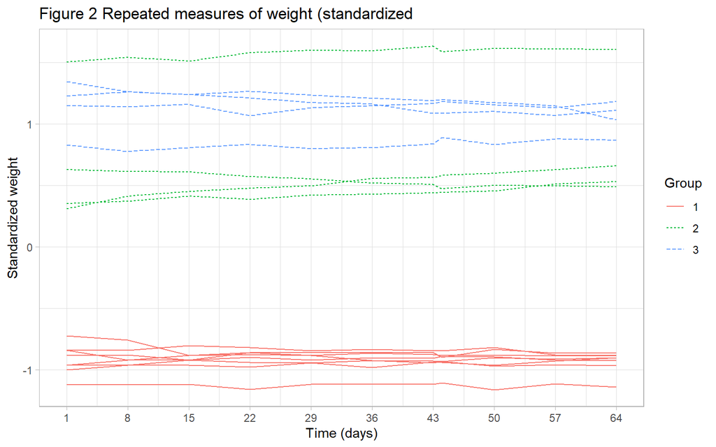

```r
p1 <- ggplot(RATSL, aes(x = Time, y = stdWeight, group = ID))
p2 <- p1 + geom_line(aes(linetype = Group, color = Group))
p3 <- p2 +  scale_x_continuous(name = "Time (days)", breaks = seq(1, 64, 7)) +
  scale_y_continuous(name = "Standardized weight")
p4 <- p3 + theme_light() + ggtitle(label = "Figure 2 Repeated measures of weight (standardized")
p4
```

```r
# Number of measurement points, baseline (week 0) included:
n <- RATSL$Time %>% unique() %>% length()

# Make a summary data:
RATSS <- RATSL %>%
  group_by(Group, Time) %>%
  summarise( mean=mean(Weight), se=sd(Weight)/sqrt(n) ) %>%
  ungroup()
glimpse(RATSS)
```

```
## Observations: 33
## Variables: 4
## $ Group <fct> 1, 1, 1, 1, 1, 1, 1, 1, 1, 1, 1, 2, 2, 2, 2, 2, 2, 2, 2,...
## $ Time  <int> 1, 8, 15, 22, 29, 36, 43, 44, 50, 57, 64, 1, 8, 15, 22, ...
## $ mean  <dbl> 250.625, 255.000, 254.375, 261.875, 264.625, 265.000, 26...
## $ se    <dbl> 4.589478, 3.947710, 3.460116, 4.100800, 3.333956, 3.5529...
```

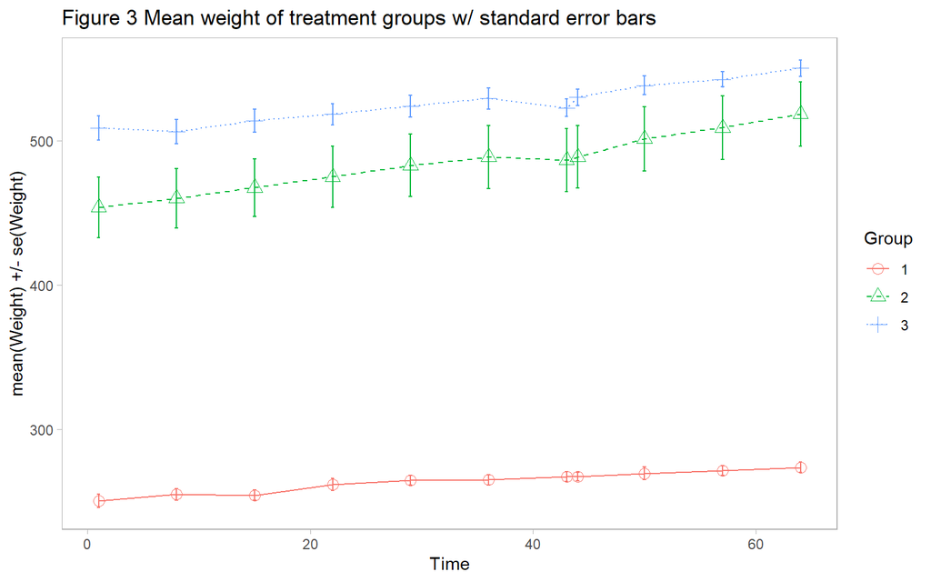

```r
p1 <- ggplot(RATSS, aes(x = Time, y = mean, linetype = Group, shape = Group, color = Group))
p2 <- p1 + geom_line()+ scale_linetype_manual(values = c(1,2,3))
p3 <- p2 + geom_point(size=3) + scale_shape_manual(values = c(1,2,3))
p4 <- p3 + geom_errorbar(aes(ymin=mean-se, ymax=mean+se, linetype="1"), width=0.3)
p5 <- p4 + theme_light() + theme(panel.grid.major = element_blank(), panel.grid.minor = element_blank())
p6 <- p5 + scale_y_continuous(name = "mean(Weight) +/- se(Weight)") +
  ggtitle(label = "Figure 3 Mean weight of treatment groups w/ standard error bars")
p6
```

The differences between the groups seem to be outside the standard error in all time points.

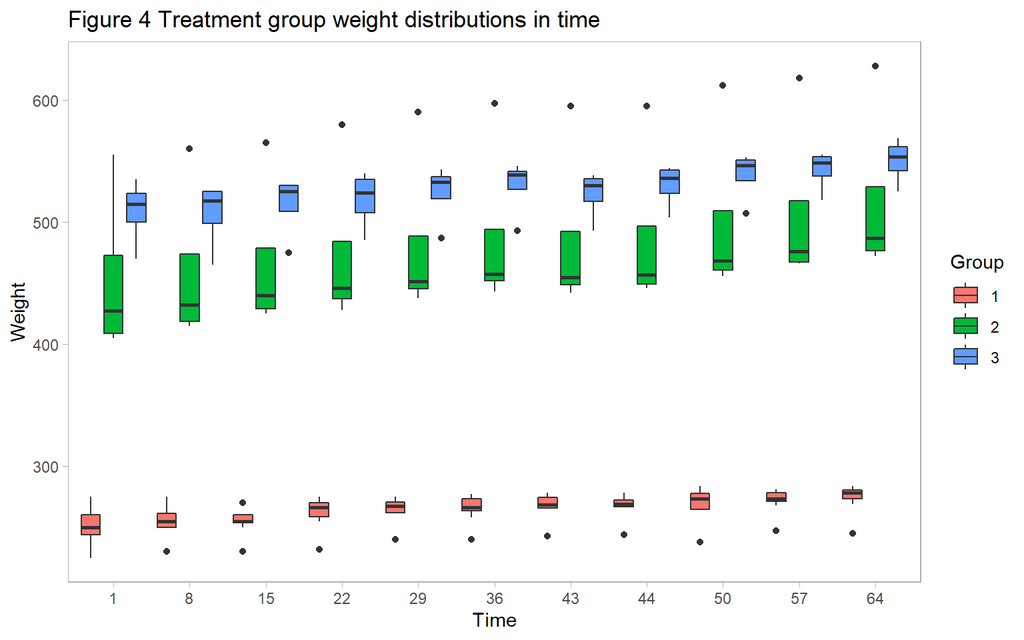

```r
p1 <- ggplot(RATSL, aes(x = factor(Time), y = Weight, fill = Group))
p2 <- p1 + geom_boxplot(position = position_dodge(width = 0.9))
p3 <- p2 + theme_light() + theme(panel.grid.major = element_blank(), panel.grid.minor = element_blank())
p4 <- p3 + scale_x_discrete(name = "Time") + ggtitle(label = "Figure 4 Treatment group weight distributions in time")
p4
```

Boxplot also shows clear differences between the groups.

```r
# Make a summary data of the post treatment weeks
RATSSS <- RATSL %>%
  filter(Time > 1) %>%
  group_by(Group, ID) %>%
  summarise( mean=mean(Weight) ) %>%
  ungroup()
glimpse(RATSSS)
```

```
## Observations: 16
## Variables: 3
## $ Group <fct> 1, 1, 1, 1, 1, 1, 1, 1, 2, 2, 2, 2, 3, 3, 3, 3
## $ ID    <fct> 1, 2, 3, 4, 5, 6, 7, 8, 9, 10, 11, 12, 13, 14, 15, 16
## $ mean  <dbl> 263.2, 238.9, 261.7, 267.2, 270.9, 276.2, 274.6, 267.5, ...
```

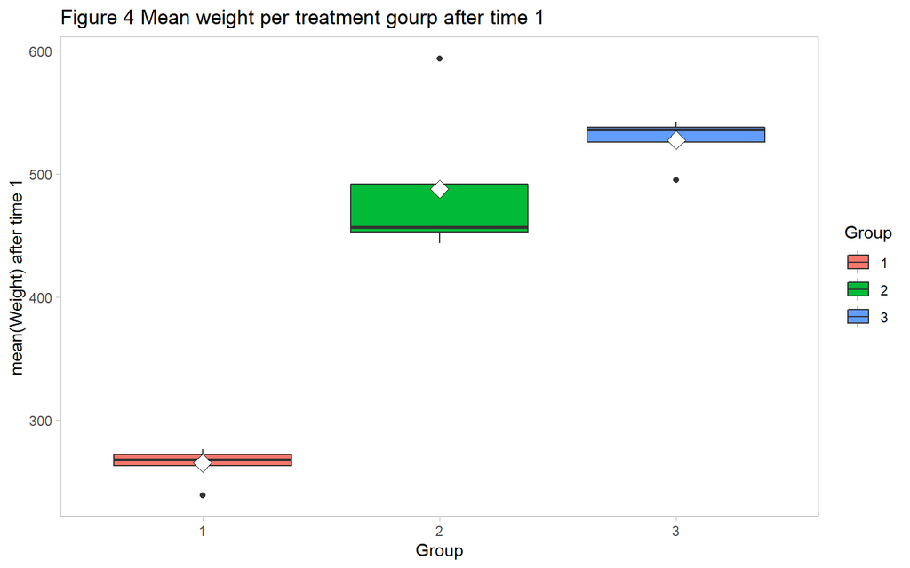

```r
p1 <- ggplot(RATSSS, aes(x = Group, y = mean))
p2 <- p1 + geom_boxplot(aes(fill = Group))
p3 <- p2 + theme_light() + theme(panel.grid.major = element_blank(), panel.grid.minor = element_blank())
p4 <- p3 + stat_summary(fun.y = "mean", geom = "point", shape=23, size=4, fill = "white")
p5 <- p4 + scale_y_continuous(name = "mean(Weight) after time 1") +
  ggtitle(label = "Figure 4 Mean weight per treatment gourp after time 1")
p5
```

The differences are also quite clear when examining the means of weight measurements per a rat after first weighing. However, there seems to be an outlier in group 2.

```r
# Remove the outliers:
RATSSS1 <- RATSSS %>%
  filter(mean < 550)
glimpse(RATSSS1)
```

```
## Observations: 15
## Variables: 3
## $ Group <fct> 1, 1, 1, 1, 1, 1, 1, 1, 2, 2, 2, 3, 3, 3, 3
## $ ID    <fct> 1, 2, 3, 4, 5, 6, 7, 8, 9, 10, 11, 13, 14, 15, 16
## $ mean  <dbl> 263.2, 238.9, 261.7, 267.2, 270.9, 276.2, 274.6, 267.5, ...
```

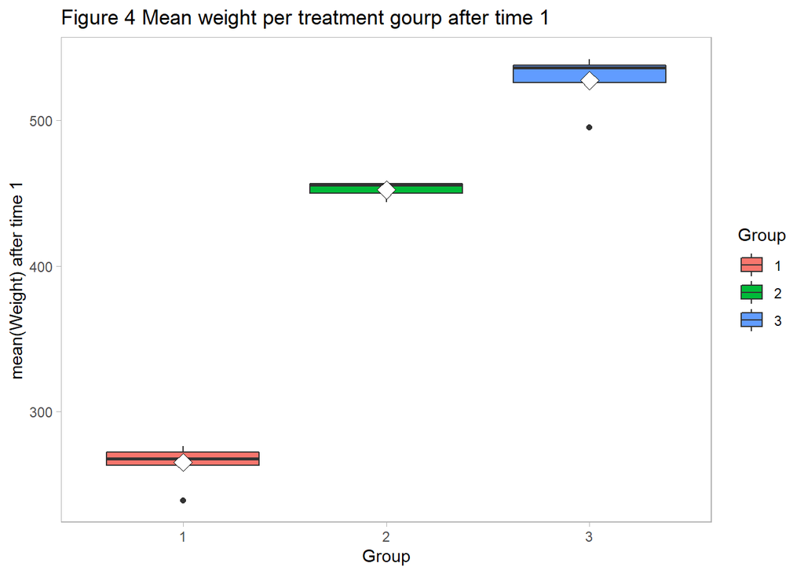

```r
p1 <- ggplot(RATSSS1, aes(x = Group, y = mean))
p2 <- p1 + geom_boxplot(aes(fill = Group))
p3 <- p2 + theme_light() + theme(panel.grid.major = element_blank(), panel.grid.minor = element_blank())
p4 <- p3 + stat_summary(fun.y = "mean", geom = "point", shape=23, size=4, fill = "white")
p5 <- p4 + scale_y_continuous(name = "mean(Weight) after time 1") +
  ggtitle(label = "Figure 4 Mean weight per treatment gourp after time 1")
p5
```

After removing the outlier, the differences seem even more clear.

### ANOVA

```r
fit1 <- lm(mean ~ Group, data = RATSSS1)
summary(fit1)
```

```
##
## Call:
## lm(formula = mean ~ Group, data = RATSSS1)
##
## Residuals:
##     Min      1Q  Median      3Q     Max
## -32.300  -2.575   3.400   8.800  14.700
##
## Coefficients:
##             Estimate Std. Error t value            Pr(>|t|)
## (Intercept)  265.025      5.086   52.11 0.00000000000000164 ***
## Group2       187.375      9.738   19.24 0.00000000021900683 ***
## Group3       262.475      8.809   29.80 0.00000000000127571 ***
## ---
## Signif. codes:  0 '***' 0.001 '**' 0.01 '*' 0.05 '.' 0.1 ' ' 1
##
## Residual standard error: 14.38 on 12 degrees of freedom
## Multiple R-squared:  0.9882, Adjusted R-squared:  0.9862
## F-statistic: 501.8 on 2 and 12 DF,  p-value: 0.000000000002721
```

```r
# same with ANOVA to get Tuckey multiple pairwise comparison
res.aov <- aov(mean ~ Group, data = RATSSS1)
summary(res.aov)
```

```
##             Df Sum Sq Mean Sq F value           Pr(>F)
## Group        2 207659  103830   501.8 0.00000000000272 ***
## Residuals   12   2483     207
## ---
## Signif. codes:  0 '***' 0.001 '**' 0.01 '*' 0.05 '.' 0.1 ' ' 1
```

```r
TukeyHSD(res.aov)
```

```
##   Tukey multiple comparisons of means
##     95% family-wise confidence level
##
## Fit: aov(formula = mean ~ Group, data = RATSSS1)
##
## $Group
##        diff       lwr      upr     p adj
## 2-1 187.375 161.39457 213.3554 0.0000000
## 3-1 262.475 238.97481 285.9752 0.0000000
## 3-2  75.100  45.79012 104.4099 0.0000498
```

```r
RATSSS1 %>% group_by(Group) %>% summarise(mean = mean(mean)) %>%
  kable(digits = 2, caption = "<b> Table 3</b> Group means") %>%
  kable_styling(bootstrap_options = c("hover", "striped"), full_width = F) %>%
  column_spec(1, bold = T, width = "10em") %>%
  column_spec(2, width = "10em")
```

**Table 3** Group means

| Group | mean |
| --- | --- |
| 1 | 265.02 |
| 2 | 452.40 |
| 3 | 527.50 |

It seems the groups are significantly different (F(2) = 501.8, p < .001). Pairwise comparison with Tukey HSD shows that all groups differ significantly from each other. However, caution is advised in inference of these results due to the small sample size. Group means can be found in Table 3.

```r
# Add the baseline from the original data as a new variable to the summary data:
RATS <- read.table("https://raw.githubusercontent.com/KimmoVehkalahti/MABS/master/Examples/data/rats.txt", header = T)
baseline <- RATS$WD1
RATSSS2 <- RATSSS %>%
  mutate(baseline)
# Fit the ANCOVA model and see the results:
fit2 <- lm(mean ~ baseline + Group, data = RATSSS2)
summary(fit2)
```

```
##
## Call:
## lm(formula = mean ~ baseline + Group, data = RATSSS2)
##
## Residuals:
##     Min      1Q  Median      3Q     Max
## -23.905  -4.194   2.190   7.577  14.800
##
## Coefficients:
##             Estimate Std. Error t value    Pr(>|t|)
## (Intercept) 33.16375   21.87657   1.516      0.1554
## baseline     0.92513    0.08572  10.793 0.000000156 ***
## Group2      34.85753   18.82308   1.852      0.0888 .
## Group3      23.67526   23.25324   1.018      0.3287
## ---
## Signif. codes:  0 '***' 0.001 '**' 0.01 '*' 0.05 '.' 0.1 ' ' 1
##
## Residual standard error: 11.68 on 12 degrees of freedom
## Multiple R-squared:  0.9936, Adjusted R-squared:  0.992
## F-statistic: 622.1 on 3 and 12 DF,  p-value: 0.0000000000001989
```

```r
anova(fit2)
```

```
## Analysis of Variance Table
##
## Response: mean
##           Df Sum Sq Mean Sq   F value             Pr(>F)
## baseline   1 253625  253625 1859.8201 0.0000000000000157 ***
## Group      2    879     439    3.2219            0.07586 .
## Residuals 12   1636     136
## ---
## Signif. codes:  0 '***' 0.001 '**' 0.01 '*' 0.05 '.' 0.1 ' ' 1
```

It seems that adding the baseline to the model removes the significant effect of the treatment group. In other words, differences between the groups can be explained with the differences in the rats’ weight in the beginning of the experiment.

## Task 2: The BPRS

Implement the analyses of Chapter 9 of MABS using the BPRS data. (0-8 points: 0-4 points for graphs or analysis results + 0-4 points for their interpretations)

### The BPRSL Data

The BPRS dataset has 360 observations and 5 variables from 40 subjects: treatment vs. no treatment group, subject id, and weekly measure of breaf psychiatric rating scale (BPRS) from week 0 (baseline) to week 8.

```r
BPRSL <- read.table("data/BPRSL.csv", sep = ",", header = T, row.names = 1)
BPRSL <- within(BPRSL, {
  subject <- factor(subject)
  treatment <- factor(treatment)
})
glimpse(BPRSL)
```

```
## Observations: 360
## Variables: 5
## $ treatment <fct> 1, 1, 1, 1, 1, 1, 1, 1, 1, 1, 1, 1, 1, 1, 1, 1, 1, 1...
## $ subject   <fct> 1, 2, 3, 4, 5, 6, 7, 8, 9, 10, 11, 12, 13, 14, 15, 1...
## $ weeks     <fct> week0, week0, week0, week0, week0, week0, week0, wee...
## $ bprs      <int> 42, 58, 54, 55, 72, 48, 71, 30, 41, 57, 30, 55, 36, ...
## $ week      <int> 0, 0, 0, 0, 0, 0, 0, 0, 0, 0, 0, 0, 0, 0, 0, 0, 0, 0...
```

```r
head(BPRSL)
```

```
##   treatment subject weeks bprs week
## 1         1       1 week0   42    0
## 2         1       2 week0   58    0
## 3         1       3 week0   54    0
## 4         1       4 week0   55    0
## 5         1       5 week0   72    0
## 6         1       6 week0   48    0
```

```r
tail(BPRSL)
```

```
##     treatment subject weeks bprs week
## 355         2      15 week8   37    8
## 356         2      16 week8   22    8
## 357         2      17 week8   43    8
## 358         2      18 week8   30    8
## 359         2      19 week8   21    8
## 360         2      20 week8   23    8
```

[figure not shown]

```r
p1 <- ggplot(BPRSL, aes(x = week, y = bprs, group = subject))
p2 <- p1 + geom_text(aes(label = treatment, color = treatment))
p3 <- p2 + scale_x_continuous(name = "BPRS", breaks = seq(0, 8, 1))
p4 <- p3 + scale_y_continuous(name = "Weight (grams)")
p5 <- p4 + theme_light()
p6 <- p5 + theme(panel.grid.major = element_blank(), panel.grid.minor = element_blank())
p6
```

```r
# Number of weeks, baseline (week 0) included
n <- BPRSL$week %>% unique() %>% length()

# Summary data with mean and standard error of bprs by treatment and week
BPRSS <- BPRSL %>%
  group_by(treatment, week) %>%
  summarise( mean = mean(bprs), se = sd(bprs)/sqrt(n)  ) %>%
  ungroup()

# Glimpse the data
glimpse(BPRSS)
```

```
## Observations: 18
## Variables: 4
## $ treatment <fct> 1, 1, 1, 1, 1, 1, 1, 1, 1, 2, 2, 2, 2, 2, 2, 2, 2, 2
## $ week      <int> 0, 1, 2, 3, 4, 5, 6, 7, 8, 0, 1, 2, 3, 4, 5, 6, 7, 8
## $ mean      <dbl> 47.00, 46.80, 43.55, 40.90, 36.60, 32.70, 29.70, 29....
## $ se        <dbl> 4.534468, 5.173708, 4.003617, 3.744626, 3.259534, 2....
```

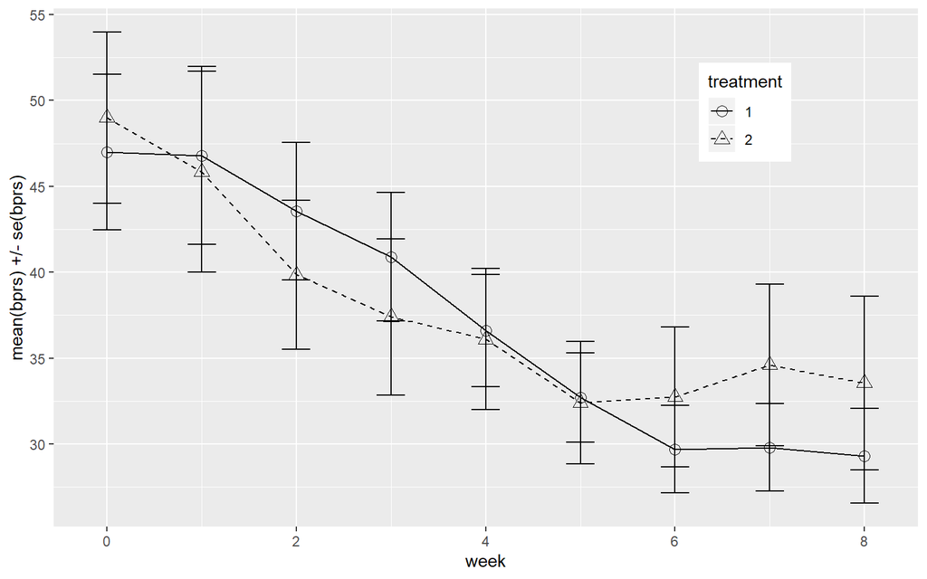

```r
# Plot the mean profiles
ggplot(BPRSS, aes(x = week, y = mean, linetype = treatment, shape = treatment)) +
  geom_line() +
  scale_linetype_manual(values = c(1,2)) +
  geom_point(size=3) +
  scale_shape_manual(values = c(1,2)) +
  geom_errorbar(aes(ymin=mean-se, ymax=mean+se, linetype="1"), width=0.3) +
  theme(legend.position = c(0.8,0.8)) +
  scale_y_continuous(name = "mean(bprs) +/- se(bprs)")
```

### Linear Mixed Effect Models

```r
BPRS_reg <- lm(bprs ~ week + treatment, data = BPRSL)
summary(BPRS_reg)
```

```
##
## Call:
## lm(formula = bprs ~ week + treatment, data = BPRSL)
##
## Residuals:
##     Min      1Q  Median      3Q     Max
## -22.454  -8.965  -3.196   7.002  50.244
##
## Coefficients:
##             Estimate Std. Error t value            Pr(>|t|)
## (Intercept)  46.4539     1.3670  33.982 <0.0000000000000002 ***
## week         -2.2704     0.2524  -8.995 <0.0000000000000002 ***
## treatment2    0.5722     1.3034   0.439               0.661
## ---
## Signif. codes:  0 '***' 0.001 '**' 0.01 '*' 0.05 '.' 0.1 ' ' 1
##
## Residual standard error: 12.37 on 357 degrees of freedom
## Multiple R-squared:  0.1851, Adjusted R-squared:  0.1806
## F-statistic: 40.55 on 2 and 357 DF,  p-value: < 0.00000000000000022
```

As we can see, there is clearly significant effect of time